# Data Visualization of Prosper Loans Data

## Preliminary Wrangling

Prosper loans provides loans to borrower's who need loans. Their interest rates vary on the creditworthy on the borrowers and the information the borrower's provide in their application form. The dataset available here has 113937 records. It is interesting to understand the basis of fixing the borrower's interest rate.

This dataset was directly available on Udacity server and was downloaded to my local computer to carry out the analysis and visualization

```python
# import all packages and set plots to be embedded inline
import numpy as np
import pandas as pd
import matplotlib.pyplot as plt
import seaborn as sb

%matplotlib inline
```

```python
df_prosper_loan = pd.read_csv('prosperLoanData.csv')
```

```python
df_prosper_loan.head(3)
```

|  | ListingKey | ListingNumber | ListingCreationDate | CreditGrade | Term | LoanStatus | ClosedDate | BorrowerAPR | BorrowerRate | LenderYield | ... | LP_ServiceFees | LP_CollectionFees | LP_GrossPrincipalLoss | LP_NetPrincipalLoss | LP_NonPrincipalRecoverypayments | PercentFunded | Recommendations | InvestmentFromFriendsCount | InvestmentFromFriendsAmount | Investors |
| --- | --- | --- | --- | --- | --- | --- | --- | --- | --- | --- | --- | --- | --- | --- | --- | --- | --- | --- | --- | --- | --- |
| 0 | 1021339766868145413AB3B | 193129 | 2007-08-26 19:09:29.263000000 | C | 36 | Completed | 2009-08-14 00:00:00 | 0.16516 | 0.158 | 0.138 | ... | -133.18 | 0.0 | 0.0 | 0.0 | 0.0 | 1.0 | 0 | 0 | 0.0 | 258 |
| 1 | 10273602499503308B223C1 | 1209647 | 2014-02-27 08:28:07.900000000 | NaN | 36 | Current | NaN | 0.12016 | 0.092 | 0.082 | ... | 0.00 | 0.0 | 0.0 | 0.0 | 0.0 | 1.0 | 0 | 0 | 0.0 | 1 |
| 2 | 0EE9337825851032864889A | 81716 | 2007-01-05 15:00:47.090000000 | HR | 36 | Completed | 2009-12-17 00:00:00 | 0.28269 | 0.275 | 0.240 | ... | -24.20 | 0.0 | 0.0 | 0.0 | 0.0 | 1.0 | 0 | 0 | 0.0 | 41 |

3 rows × 81 columns

```python
df_prosper_loan.shape
```

```
(113937, 81)
```

```python
df_prosper_loan.info()
```

```
<class 'pandas.core.frame.DataFrame'>
RangeIndex: 113937 entries, 0 to 113936
Data columns (total 81 columns):
 #   Column                               Non-Null Count   Dtype
---  ------                               --------------   -----
 0   ListingKey                           113937 non-null  object
 1   ListingNumber                        113937 non-null  int64
 2   ListingCreationDate                  113937 non-null  object
 3   CreditGrade                          28953 non-null   object
 4   Term                                 113937 non-null  int64
 5   LoanStatus                           113937 non-null  object
 6   ClosedDate                           55089 non-null   object
 7   BorrowerAPR                          113912 non-null  float64
 8   BorrowerRate                         113937 non-null  float64
 9   LenderYield                          113937 non-null  float64
```

[output cut: 73 more lines]

## Data Cleaning

```python
df = df_prosper_loan.copy()
```

```python
#Remove all columns that are not of interest to the analysis
df = df.drop(['ClosedDate','EstimatedEffectiveYield','EstimatedLoss', 'EstimatedReturn','GroupKey', 'FirstRecordedCreditLine', 'CurrentCreditLines',
              'OpenCreditLines','TotalCreditLinespast7years',
             'InquiriesLast6Months', 'TotalInquiries','DelinquenciesLast7Years', 'PublicRecordsLast10Years', 'PublicRecordsLast12Months',
             'TradesOpenedLast6Months','TradesOpenedLast6Months','LoanCurrentDaysDelinquent','LoanFirstDefaultedCycleNumber'], axis =1)
```

```python
df.info()
```

```
<class 'pandas.core.frame.DataFrame'>
RangeIndex: 113937 entries, 0 to 113936
Data columns (total 62 columns):
 #   Column                               Non-Null Count   Dtype
---  ------                               --------------   -----
 0   ListingKey                           113937 non-null  object
 1   ListingNumber                        113937 non-null  int64
 2   ListingCreationDate                  113937 non-null  object
 3   Term                                 113937 non-null  int64
 4   LoanStatus                           113937 non-null  object
 5   BorrowerAPR                          113912 non-null  float64
 6   BorrowerRate                         113937 non-null  float64
 7   LenderYield                          113937 non-null  float64
 8   ProsperRating (numeric)              84853 non-null   float64
 9   ProsperScore                         84853 non-null   float64
```

[output cut: 54 more lines]

### What is the structure of your dataset?

The dataset most contains floats, with few columns with int, bool and object datatypes.The object datatypes contains nominal categorical datatypes. For example, EmploymentStatus is a nominal categorical datatype with values such as 'Employed', 'Part-Time', 'Full-Time', and few more.

There are also ordinal categorical data such as ProsperRating (numeric) reprsented as float datatype. The numbers represent 0- NA, 1- HR, 2 - E,3 - D, 4 - C,5 - B,6 - A,7 - AA where higher number represents best and lower number represents worst.

### What is/are the main feature(s) of interest in your dataset?

The main idea is to find out more about the BorrowerRate or the borrower's interest rate on the loan.

### What features in the dataset do you think will help support your investigation into your feature(s) of interest?

There are a few parameters such as Occupation, EmploymentStatus, ProsperRating, ProsperScore, Term, CreditScoreLower and CreditScoreUpper that may impact the BorrowerRate.

## Univariate Exploration

> In this section, investigate distributions of individual variables. If you see unusual points or outliers, take a deeper look to clean things up and prepare yourself to look at relationships between variables.

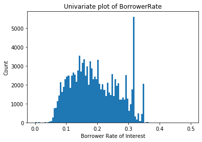

```python
bins = np.arange(0, df.BorrowerRate.max()+0.005, 0.005)
plt.hist(data = df, x = 'BorrowerRate', bins = bins)
plt.xlabel('Borrower Rate of Interest')
plt.ylabel('Count')
plt.title('Univariate plot of BorrowerRate');
```

From the above plot, an observation can be made that the graph is almost normally distributed with its median around 0.15 and 0.17. Also, a huge peak at 0.31 can be observed.

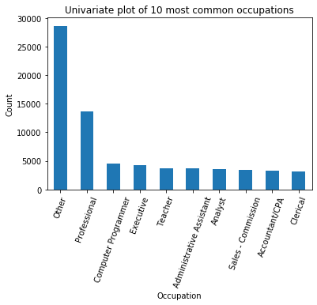

```python
df.Occupation.value_counts()[0:10].plot(kind = 'bar')
plt.title('Univariate plot of 10 most common occupations')
plt.xlabel('Occupation')
plt.ylabel('Count')
plt.xticks(rotation = 70);
```

Other seems to be the highest occupation that people have chosen while filling their application followed by professional while the remaining occupations seem to be around the same number and below 5000.

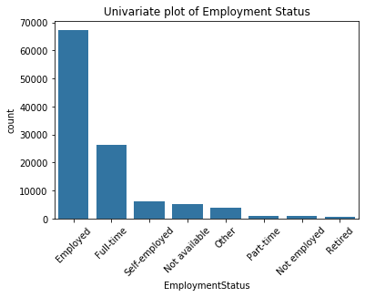

```python
#Employment Status - Seaborn countplot
base_color = sb.color_palette()[0]
employment_order = df.EmploymentStatus.value_counts().index
sb.countplot(data = df, x = 'EmploymentStatus', color = base_color, order = employment_order)
plt.title('Univariate plot of Employment Status')
plt.xticks(rotation = 45);
```

The order of the index arranged in the graph is descending. It can be observed that most people applying for prosper loan are employed or full-time with very few in the remaining categories.

Below code resource - https://stackoverflow.com/questions/38082602/plotting-multiple-different-plots-in-one-figure-using-seaborn

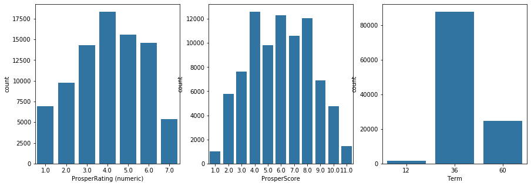

```python
#Prosper Rating and Prosper Score Seaborn countplot
base_color = sb.color_palette()[0]
fig, axs = plt.subplots(ncols=3, figsize = [15,5])
#Prosper Rating
sb.countplot(data = df, x = 'ProsperRating (numeric)', color = base_color, ax = axs[0]);

#Prosper Score
sb.countplot(data = df, x = 'ProsperScore', color = base_color, ax = axs[1]);

#Term
sb.countplot(data = df, x = 'Term', color = base_color, ax = axs[2]);
```

Prosper rating appears to be normally distributed. On the other hand, prosper score could have been normally distributed if it didn't have peaks at 4.0 and 8.0. Most of the people have gone with 36months term for their loan and few others with 60months.

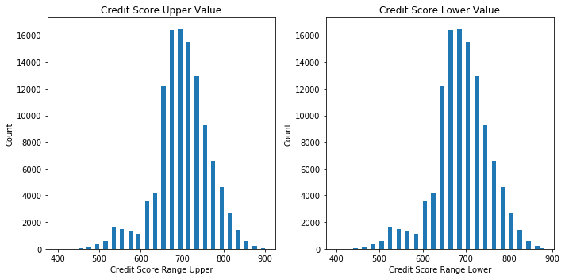

```python
#Credit Score Upper and Lower - Histogram
plt.figure(figsize = [10,5])
#credit score upper range
plt.subplot(1,2,1)
up_bin = np.arange(400, df.CreditScoreRangeUpper.max()+10,10)
plt.hist(data = df, x = 'CreditScoreRangeUpper', bins = up_bin)
plt.title('Credit Score Upper Value')
plt.xlabel('Credit Score Range Upper')
plt.ylabel('Count')

#credit score lower range
plt.subplot(1,2,2)
low_bin = np.arange(400, df.CreditScoreRangeLower.max()+10,10)
plt.hist(data = df, x = 'CreditScoreRangeLower', bins = low_bin)
plt.title('Credit Score Lower Value')
plt.xlabel('Credit Score Range Lower')
plt.ylabel('Count')

plt.tight_layout()
```

### Of the features you investigated, were there any unusual distributions? Did you perform any operations on the data to tidy, adjust, or change the form of the data? If so, why did you do this?

There aren't any unusual distributions or changes performed.

## Bivariate Exploration

> In this section, investigate relationships between pairs of variables in your data. Make sure the variables that you cover here have been introduced in some fashion in the previous section (univariate exploration).

```python
n_vars = ['BorrowerRate', 'Term', 'EmploymentStatus', 'ProsperScore','ProsperRating (numeric)',
            'CreditScoreRangeUpper']
```

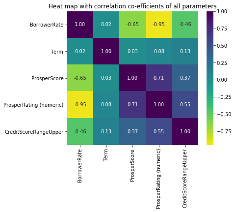

```python
#correlation plot using heat map
plt.figure(figsize = [6,5])
plt.title('Heat map with correlation co-efficients of all parameters')
sb.heatmap(df[n_vars].corr(),annot = True, fmt = '.2f', cmap = 'viridis_r', center = 0);
```

The above correlation heat map shows that the borrower rate of interest has negative correlation with all the other factors except term. This makes sense because the rate of interest reduces when an individual has a good prosper score, prosper rating and credit score. Also the interest rate for the borrower will be high if the term for borrowing is high. That's why we can see from the earlier univariate plot that more people have opted for 36months for their rate of interest

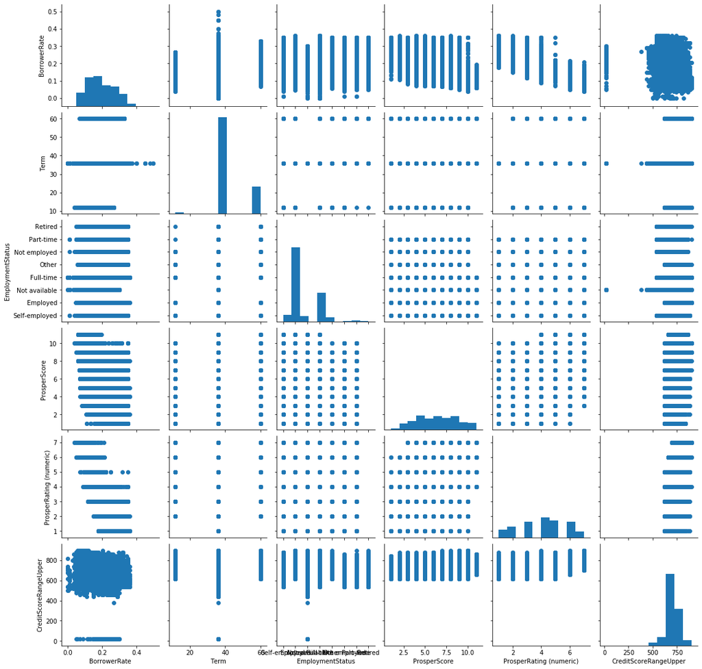

```python
#PairGrid of parameters
sample = np.random.choice(df.shape[0], 550, replace = False)
df_sample = df.loc[sample,:]
g = sb.PairGrid(data = df, vars = n_vars)
g.map_diag(plt.hist)
g.map_offdiag(plt.scatter);
```

From the above plot matrix, we can understand the relationship between each and every parameter. They are positively or negatively related to one other.

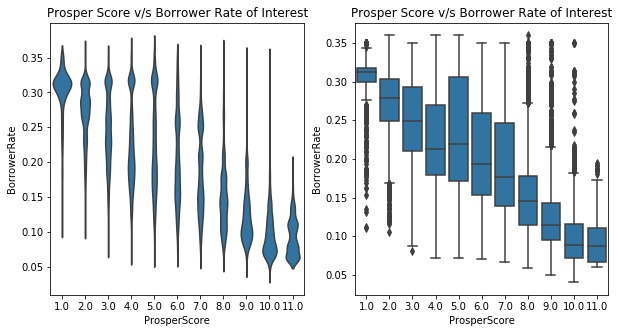

```python
plt.figure(figsize = [10,5])
base_color = sb.color_palette()[0]

#violin plot for BorrowerRate and ProsperScore
plt.subplot(1,2,1)
ax1 = sb.violinplot(data = df, x = 'ProsperScore', y = 'BorrowerRate', color = base_color, inner = None)
plt.title('Prosper Score v/s Borrower Rate of Interest')

#box plot for BorrowerRate and ProsperScore
plt.subplot(1,2,2)
sb.boxplot(data = df, x = 'ProsperScore', y = 'BorrowerRate', color = base_color);
plt.title('Prosper Score v/s Borrower Rate of Interest');
```

From the above violin and box plot we can observe that the value of Borrower Rate is higher when the prosper score is lower and vice versa showing a negative relationship between the two.

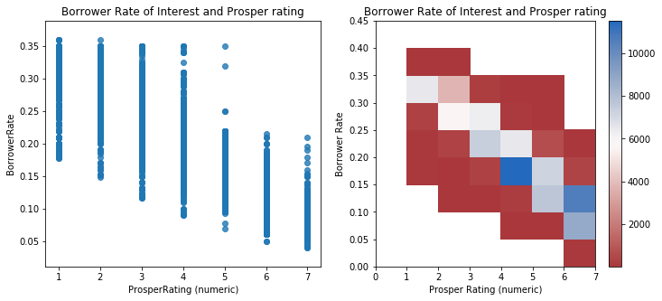

```python
#Relationship between Borrower Rate and Prosper rating
plt.figure(figsize = [12,5])

plt.subplot(1,2,1)
sb.regplot(data = df, x = 'ProsperRating (numeric)', y = 'BorrowerRate', fit_reg = False)
plt.title('Borrower Rate of Interest and Prosper rating');


plt.subplot(1,2,2)
xbin = np.arange(0, df['ProsperRating (numeric)'].max()+1, 1)
ybin = np.arange(0, df['BorrowerRate'].max(), 0.05)
plt.hist2d(data = df, x = 'ProsperRating (numeric)', y = 'BorrowerRate',
           bins = [xbin, ybin], cmap = 'vlag_r', cmin = 0.5)
plt.colorbar()
plt.xlabel('Prosper Rating (numeric)')
plt.ylabel('Borrower Rate')
plt.title('Borrower Rate of Interest and Prosper rating');
```

Although the first figure conveys the relationship between prosper rating and borrower rate, the second plot helps to understand where the count has been maximum for a certain prosper raing and borrowe rate. We can see that prosper rating has a negative relationship with borrower rate from the first plot but from the secon we can understand that the there are lot of people with prosper rating between 4 and 5 and they have got a borrower rate of interest around 0.15 and 0.20

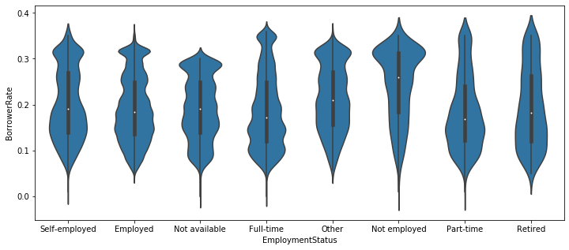

```python
#relationship between borrower rate with employment status and credit score range upper
plt.figure(figsize = [12,5])
base_color = sb.color_palette()[0]
#violin plot for employment status and borrower rate
sb.violinplot(data = df, x = 'EmploymentStatus', y = 'BorrowerRate', color = base_color);
```

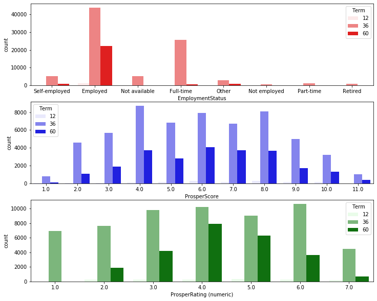

```python
#Relationship between term and employment status, prosper score and prosper rating
fig, axs = plt.subplots(nrows=3, figsize = [12,10])
#Prosper Rating
sb.countplot(data = df, x = 'EmploymentStatus', hue = 'Term', color = 'red', ax = axs[0]);

#Prosper Score
sb.countplot(data = df, x = 'ProsperScore', hue = 'Term', color = 'blue', ax = axs[1]);

#Term
sb.countplot(data = df, x = 'ProsperRating (numeric)', hue = 'Term', color = 'green', ax = axs[2]);
```

In each of the above plots, 36 months loan seems to be a popular option for people employed or full-time. Irrespective of the propser score or rating , people seem to prefer 36 months loan.

### Talk about some of the relationships you observed in this part of the investigation. How did the feature(s) of interest vary with other features in the dataset?

Using the correlation heatmap and the plot matrix in this section helped to understand the relationship between BorrowerRate and other parameters. From the correlation heat map it was evident that BorrowerRate was negatively correlated with all the parameters except the term of loan. ProsperRating (numeric) showed the highest negative correlation (-0.95) with BorrowerRate. The negative relationship was quite evident from the plot matrix as well.

### Did you observe any interesting relationships between the other features (not the main feature(s) of interest)?

Yes, it was observed that the term was positively correlated with the other parameters however this was less significant. Term period of loan did not quite matter to effect the other parameters as people mostly chose 36 months.

## Multivariate Exploration

> Create plots of three or more variables to investigate your data even further. Make sure that your investigations are justified, and follow from your work in the previous sections.

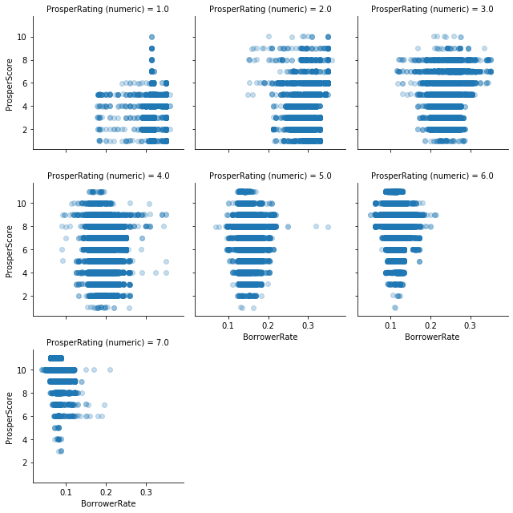

```python
g = sb.FacetGrid(data = df, col = 'ProsperRating (numeric)', col_wrap =3, size = 3)
g.map(sb.regplot, 'BorrowerRate', 'ProsperScore', y_jitter = 0.04,fit_reg = False, scatter_kws = {'alpha' :1/4})
g.set_xlabels('BorrowerRate')
g.set_ylabels('ProsperScore');
```

Low ProsperRating (numeric)=1 & 2 have high BorrowerRate at low ProsperScore. Whereas a higher ProsperRating (numeric) such as 6 &7 have a low BorrowerRate at high ProsperScore.

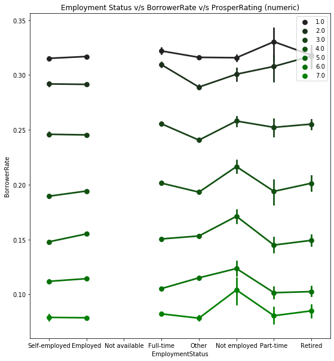

```python
plt.figure(figsize = [9,10])
sb.pointplot(data = df, x = 'EmploymentStatus', y = 'BorrowerRate',
             hue = 'ProsperRating (numeric)', color = 'green')
plt.legend (loc = 1)
plt.title('Employment Status v/s BorrowerRate v/s ProsperRating (numeric)');
```

The above plot shows a relationship between Employment Status, prosper rating and borrower rate of interest. It is interesting to observe that the rate of interest is low for high prosper rating irrespective of the employment status of the applicant.

### Talk about some of the relationships you observed in this part of the investigation. Were there features that strengthened each other in terms of looking at your feature(s) of interest?

In the first relationship between the prosper score, prosper rating and borrower rate of interest, it was evident that a low borrower rate of interest was possible with a high prosper rating and high prosper score and vice versa. This is exactly what we saw even in case of bivariate relationship between borrower rate and prosper rating and borrower rate and prosper score.

### Were there any interesting or surprising interactions between features?

# https://stackoverflow.com/questions/38082602/plotting-multiple-different-plots-in-one-figure-using-seaborn